# Llamados atendidos por violencia 2017-2022

Pedro Burgos

#### *Paquetes a utilizar*

```r
library(dplyr)
library(ggplot2)
library(plotrix)
library(forcats)
library(GGally)
library(lubridate)
```

#### *Cargo DS y verifico*

```r
ds<-read.csv(file = "llamados-atendidos-violencia-familiar-unificado-201701-202208.csv",stringsAsFactors = FALSE)

head(ds)
```

|  | caso_id | llamante_descripcion | llamante_genero | llamante_vinculo_ninios_presentes | violencia_tipo | victima_edad | victima_rango_etario | victima_genero | victima_cantidad | agresor_cantidad | agresor_genero | agresor_relacion_victima | llamado_derivacion | llamado_fecha | llamado_hora | llamado_provincia | llamado_provincia_id |
| --- | --- | --- | --- | --- | --- | --- | --- | --- | --- | --- | --- | --- | --- | --- | --- | --- | --- |
| 1 | 344552 | Comisaría | Masculino | Otra/o no familiar | Física y psicológica | 27 | 18 a 29 años | Femenino | 3 | 1 | Masculino | Pareja | La víctima no aceptó la intervención del Equipo Móvil | 2017-01-01 | 1:37 |  | NA |
| 2 | 344553 | Comisaría | Femenino | Sin datos | Física y psicológica | Sin dato | Sin dato | Femenino | 2 | 1 | Masculino | Hermano/a | Llamante solicitó información y/o orientación | 2017-01-01 | 6:42 |  | NA |
| 3 | 344554 | Víctima | Femenino | Madre | Física y psicológica | Sin dato | Sin dato | Femenino | 1 | 1 | Masculino | Pareja | Llamante solicitó información y/o orientación | 2017-01-01 | 6:48 |  | NA |
| 4 | 344555 | Víctima | Femenino | No hay niñas/os | Física y psicológica | Sin dato | Sin dato | Femenino | 1 | 1 | Masculino | Pareja | Llamante solicitó información y/o orientación | 2017-01-01 | 6:54 |  | NA |
| 5 | 344556 | Comisaría | Masculino | Otra/o no familiar | Psicológica | Sin dato | Sin dato | Masculino | 1 | 1 | Femenino | Madre | Llamante solicitó información y/o orientación | 2017-01-01 | 7:11 |  | NA |
| 6 | 344557 | Comisaría | Masculino | Otra/o no familiar | Física y psicológica | 35 | 30 a 39 años | Femenino | 4 | 1 | Masculino | Pareja | La víctima no aceptó la intervención del Equipo Móvil | 2017-01-01 | 7:23 |  | NA |

#### *Nombres de cada columna de mi DS*

```r
names(ds)
```

```
 [1] "caso_id"                           "llamante_descripcion"
 [3] "llamante_genero"                   "llamante_vinculo_ninios_presentes"
 [5] "violencia_tipo"                    "victima_edad"
 [7] "victima_rango_etario"              "victima_genero"
 [9] "victima_cantidad"                  "agresor_cantidad"
[11] "agresor_genero"                    "agresor_relacion_victima"
[13] "llamado_derivacion"                "llamado_fecha"
[15] "llamado_hora"                      "llamado_provincia"
[17] "llamado_provincia_id"
```

#### *Información de contenido de cada columna*

```r
str(ds)
```

```
'data.frame':   49287 obs. of  17 variables:
 $ caso_id                          : int  344552 344553 344554 344555 344556 344557 344558 344559 NA 344561 ...
 $ llamante_descripcion             : chr  "Comisaría" "Comisaría" "Víctima" "Víctima" ...
 $ llamante_genero                  : chr  "Masculino" "Femenino" "Femenino" "Femenino" ...
 $ llamante_vinculo_ninios_presentes: chr  "Otra/o no familiar" "Sin datos" "Madre" "No hay niñas/os" ...
 $ violencia_tipo                   : chr  "Física y psicológica" "Física y psicológica" "Física y psicológica" "Física y psicológica" ...
 $ victima_edad                     : chr  "27" "Sin dato" "Sin dato" "Sin dato" ...
 $ victima_rango_etario             : chr  "18 a 29 años" "Sin dato" "Sin dato" "Sin dato" ...
 $ victima_genero                   : chr  "Femenino" "Femenino" "Femenino" "Femenino" ...
 $ victima_cantidad                 : int  3 2 1 1 1 4 2 1 2 3 ...
 $ agresor_cantidad                 : int  1 1 1 1 1 1 1 1 1 1 ...
 $ agresor_genero                   : chr  "Masculino" "Masculino" "Masculino" "Masculino" ...
 $ agresor_relacion_victima         : chr  "Pareja" "Hermano/a" "Pareja" "Pareja" ...
 $ llamado_derivacion               : chr  "La víctima no aceptó la intervención del Equipo Móvil" "Llamante solicitó información y/o orientación" "Llamante solicitó información y/o orientación" "Llamante solicitó información y/o orientación" ...
 $ llamado_fecha                    : chr  "2017-01-01" "2017-01-01" "2017-01-01" "2017-01-01" ...
 $ llamado_hora                     : chr  "1:37" "6:42" "6:48" "6:54" ...
 $ llamado_provincia                : chr  "" "" "" "" ...
 $ llamado_provincia_id             : logi  NA NA NA NA NA NA ...
```

```r
#Quiero contar el número de filas que hay en ds en total
count(ds)
```

| n |
| --- |
| 49287 |

```r
#Vemos cuanto na hay por columna
apply(is.na(ds),2,sum)
```

```
                          caso_id              llamante_descripcion                   llamante_genero
                                1                                 0                                 0
llamante_vinculo_ninios_presentes                    violencia_tipo                      victima_edad
                                0                                 0                                 0
             victima_rango_etario                    victima_genero                  victima_cantidad
                                0                                 0                                 0
                 agresor_cantidad                    agresor_genero          agresor_relacion_victima
                                0                                 0                                 0
               llamado_derivacion                     llamado_fecha                      llamado_hora
                                0                                 0                                 0
                llamado_provincia              llamado_provincia_id
                                0                             49287
```

```r
#Directamente puedo decir que una  columna esta sin usar y borrarla
ds$llamado_provincia_id<-NULL
```

#### *Guardo en variables cada columna por comodidad*

```r
id<-ds$caso_id
llamante_descripcion<-ds$llamante_descripcion
llamante_genero<-ds$llamante_genero
llamante_vinculo_ninios_presentes<-ds$llamante_vinculo_ninios_presentes
violencia_tipo<-ds$violencia_tipo
victima_edad<-ds$victima_edad
victima_rango_etario<-ds$victima_rango_etario
victima_genero<-ds$victima_genero
victima_cantidad<-ds$victima_cantidad
agresor_cantidad<-ds$agresor_cantidad
agresor_genero<-ds$agresor_genero
agresor_relacion_victima<-ds$agresor_relacion_victima
llamado_derivacion<-ds$llamado_derivacion
llamado_fecha<-as.Date(ds$llamado_fecha)
llamado_hora<-ds$llamado_hora
llamado_provincia<-ds$llamado_provincia
```

#### *Para empezar con el análisis me hago preguntas*

#### *¿Con qué frecuencia ocurre las llamadas y cuál es el género del que llama?*

#### *¿Podemos ver cuantas veces el género del llamante resulta ser el género agresor también?*

```r
barplot(table(llamante_genero),ylim=c(0,40000) ,main = "LLamadas y Agresion", xlab = "Generos", ylab = "Frecuencia de llamadas")
par(new=TRUE)
```

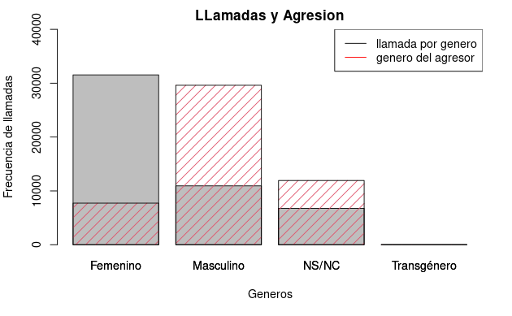

```r
barplot(table(agresor_genero),ylim=c(0,40000), col = 2,
     axes = FALSE, # Sin ejes
     bty = "n",    # Sin caja
     xlab = "", ylab = "",density=10) # Sin etiquetas de los ejes
legend("topright", legend = c("llamada por genero", "genero del agresor"),
       lwd = 1, col = c("black", "red"))
```

```r
#Mejor vista
barplot(table(llamante_genero),ylim=c(0,60) ,sub = "LLamadas y Agresion",font.sub=4,cex.sub=1, xlab = "Generos", ylab = "Frecuencia de llamadas")
par(new=TRUE)
```

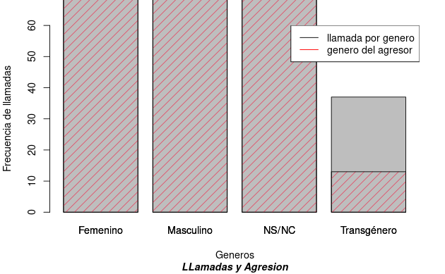

```r
barplot(table(agresor_genero),ylim=c(0,60), col = 2,
     axes = FALSE, # Sin ejes
     bty = "n",    # Sin caja
     xlab = "", ylab = "",density=10) # Sin etiquetas de los ejes
legend("topright", legend = c("llamada por genero", "genero del agresor"),
       lwd = 1, col = c("black", "red"))
```

#### *Podemos notar que normalmente el género que llama es el femenino, y el género del agresor normalmente es masculino.*

#### *Luego en el caso más chico es el transgénero, tanto como “violentado y violentador”*

#### *Para poder seguir me gustaría saber cuál fue la 1.ª y última fecha registrada en el DS*

```r
first(llamado_fecha)
```

```
[1] "2017-01-01"
```

```r
last(llamado_fecha)
```

```
[1] "2022-08-31"
```

#### *Ahora con ese dato sabemos que el DS llega hasta agosto del 2022,entonces podemos la frecuencia de llamadas que se hizo por mes y año*

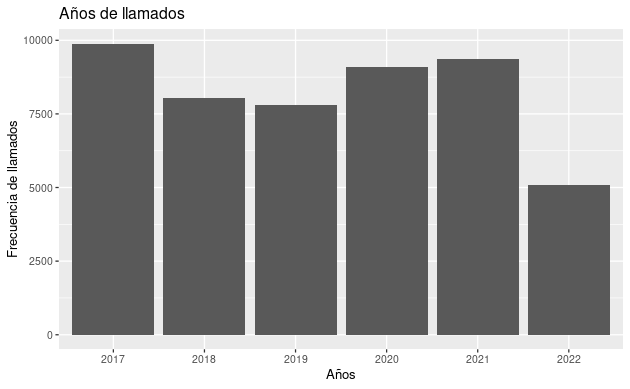

```r
ano<-format(llamado_fecha, format = "%Y")
ggplot(ds,aes(ano))+geom_bar()+
ylab("Frecuencia de llamados") +
xlab("Años") +
ggtitle("Años de llamados")
```

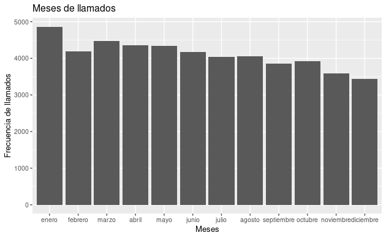

```r
meses_fecha<-months(llamado_fecha)
ggplot(ds,aes(x=fct_inorder(meses_fecha)))+geom_bar()+
ylab("Frecuencia de llamados") +
xlab("Meses") +
ggtitle("Meses de llamados")
```

#### *Siguiendo con las fechas podríamos segmentar por género*

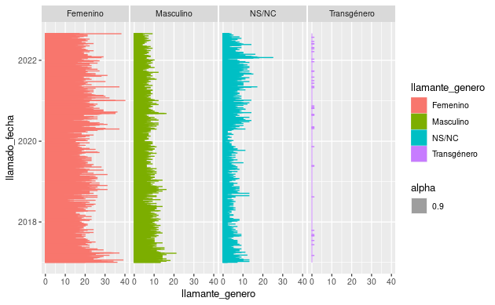

```r
options(scipen=10)
relacion_cant_agresor_fecha<-select(ds,llamante_genero,llamado_fecha)
relacion_cant_agresor_fecha$llamado_fecha<-as.Date(relacion_cant_agresor_fecha$llamado_fecha)

g<-ggpairs(relacion_cant_agresor_fecha, aes(color=llamante_genero,alpha=0.9),title = "Relacion del genero que realiza las llamadas y las Fechas",
lower=list(combo=wrap("facethist", binwidth=0.8)),columns = c(1,2))
g[2,1]+aes(color=llamante_genero)
```

#### *Un tema interesante a tocar es Tipo de violencias, así que veamos que contiene el DS*

```r
unique(violencia_tipo)
```

```
 [1] "Física y psicológica"                    "Psicológica"
 [3] "No aplica"                               "Económica, física y psicológica"
 [5] "Otras"                                   "Económica y psicológica"
 [7] "Sexual y psicológica"                    "Sexual, económica y psicológica"
 [9] "No es un caso de Violencia Familiar"     "Física, sexual y psicológica"
[11] ""                                        "Física, psicológica y económica"
[13] "Económica, Física y psicológica"         "No Aplica"
[15] "Física, sexual, psicológica y económica"
```

#### *Como se repite No Aplica, solo con una diferencia de mayúscula y minúscula, modifico el DS para que solo existe un “NO APLICA”*

```r
ds$violencia_tipo<-replace(ds$violencia_tipo, ds$violencia_tipo== "No Aplica", "No aplica")
violencia_tipo<-ds$violencia_tipo
unique(violencia_tipo)
```

```
 [1] "Física y psicológica"                    "Psicológica"
 [3] "No aplica"                               "Económica, física y psicológica"
 [5] "Otras"                                   "Económica y psicológica"
 [7] "Sexual y psicológica"                    "Sexual, económica y psicológica"
 [9] "No es un caso de Violencia Familiar"     "Física, sexual y psicológica"
[11] ""                                        "Física, psicológica y económica"
[13] "Económica, Física y psicológica"         "Física, sexual, psicológica y económica"
```

```r
saco_promedios<-function(bar1){
  return(mean(bar1))
}

saco_cantidad<-function(bar2){
  return(length(bar2))
}

saco_suma<-function(bar3){
  return(sum(bar3))
}


caracteriza<-c("Promedio","#casos_Victimas","Sumatoria")
```

```r
nombre_tipo_violencia<-unique(violencia_tipo)
lista_De_tipvio_totales<-list()

for (j in 1:length(unique(violencia_tipo))) {
  w<-ds[violencia_tipo == nombre_tipo_violencia[j],]$victima_cantidad
  lista_De_tipvio_totales<-c(lista_De_tipvio_totales,list(w))
}

viotip <-matrix(NA,nrow=length(nombre_tipo_violencia),
                ncol=length(c(caracteriza)))

colnames(viotip)<-c(caracteriza)
rownames(viotip)<-nombre_tipo_violencia

vec_unido<-function(bar5){
  vec_union_1<-c(saco_promedios(bar5),
                 saco_cantidad(bar5),
                 saco_suma(bar5))
  return(vec_union_1)
}

violencia <- viotip
for (i_1 in 1:length(nombre_tipo_violencia)) {
        violencia[i_1,]<-vec_unido(lista_De_tipvio_totales[[i_1]])
}
violencia
```

```
                                           Promedio #casos_Victimas Sumatoria
Física y psicológica                    1.755226859           23054     40465
Psicológica                             1.460515378           15639     22841
No aplica                               0.002446982            8582        21
Económica, física y psicológica         2.055851064             376       773
Otras                                   1.292517007             147       190
Económica y psicológica                 1.640371230             431       707
Sexual y psicológica                    1.680000000             250       420
Sexual, económica y psicológica         2.266666667              15        34
No es un caso de Violencia Familiar     1.066666667              30        32
Física, sexual y psicológica            2.032327586             464       943
                                        1.900000000              20        38
Física, psicológica y económica         2.112903226             186       393
Económica, Física y psicológica         1.940476190              84       163
Física, sexual, psicológica y económica 1.777777778               9        16
```

#### *Con la información de cantidad de víctima y la de tipo de violencia, me cuestiono cuanto casos de víctimas hay y en total cuantas víctimas hay*

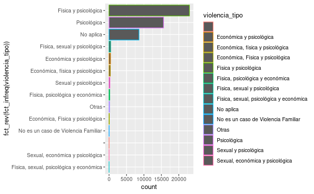

```r
ggplot(ds,aes(fct_rev(fct_infreq(violencia_tipo)),color=violencia_tipo))+geom_bar()+ coord_flip()
```

#### *Para finalizar me gustaría ver modelos de regresión lineal donde relación el género de la víctima con la relacion_victima y género del agresor*

```r
q<-replace(ds$victima_genero, ds$victima_genero== "Femenino", 1)
q<-replace(q, q== "Masculino", 2)
q<-replace(q, q== "NS/NC", 3)
q<-replace(q, q== "Transgénero", 4)

summary(lm(q ~ agresor_relacion_victima , data = ds))
```

```
Call:
lm(formula = q ~ agresor_relacion_victima, data = ds)

Residuals:
     Min       1Q   Median       3Q      Max
-1.75045 -0.16871 -0.09965  0.24955  2.90035

Coefficients:
                                               Estimate Std. Error t value Pr(>|t|)
(Intercept)                                    1.476923   0.037115  39.793  < 2e-16 ***
agresor_relacion_victimaEx pareja             -0.377275   0.037499 -10.061  < 2e-16 ***
agresor_relacion_victimaHermana/o             -0.169231   0.108208  -1.564    0.118
agresor_relacion_victimaHermano/a             -0.245338   0.039189  -6.260 3.87e-10 ***
agresor_relacion_victimaHijo/a                -0.308217   0.038262  -8.055 8.10e-16 ***
agresor_relacion_victimaMadrastra              0.094505   0.119033   0.794    0.427
agresor_relacion_victimaMadre                  0.038380   0.037926   1.012    0.312
agresor_relacion_victimaNS/NC                  1.273525   0.037422  34.031  < 2e-16 ***
agresor_relacion_victimaOtro/a conviviente    -0.177160   0.041180  -4.302 1.70e-05 ***
agresor_relacion_victimaOtro/a no conviviente -0.264633   0.039899  -6.633 3.33e-11 ***
agresor_relacion_victimaPadrastro             -0.019476   0.042258  -0.461    0.645
agresor_relacion_victimaPadre                 -0.001297   0.038098  -0.034    0.973
agresor_relacion_victimaPareja                -0.375264   0.037407 -10.032  < 2e-16 ***
---
Signif. codes:  0 ‘***’ 0.001 ‘**’ 0.01 ‘*’ 0.05 ‘.’ 0.1 ‘ ’ 1

Residual standard error: 0.5183 on 49274 degrees of freedom
Multiple R-squared:  0.6252,    Adjusted R-squared:  0.6251
F-statistic:  6850 on 12 and 49274 DF,  p-value: < 2.2e-16
```

```r
summary(lm(q ~ agresor_genero , data = ds))
```

```
Call:
lm(formula = q ~ agresor_genero, data = ds)

Residuals:
    Min      1Q  Median      3Q     Max
-1.7621 -0.1339 -0.1339  0.2379  2.8661

Coefficients:
                           Estimate Std. Error t value Pr(>|t|)
(Intercept)                1.458932   0.005758 253.367  < 2e-16 ***
agresor_generoMasculino   -0.325067   0.006466 -50.271  < 2e-16 ***
agresor_generoNS/NC        1.303201   0.007392 176.299  < 2e-16 ***
agresor_generoTransgénero  0.617992   0.140539   4.397 0.000011 ***
---
Signif. codes:  0 ‘***’ 0.001 ‘**’ 0.01 ‘*’ 0.05 ‘.’ 0.1 ‘ ’ 1

Residual standard error: 0.5063 on 49283 degrees of freedom
Multiple R-squared:  0.6423,    Adjusted R-squared:  0.6423
F-statistic: 2.95e+04 on 3 and 49283 DF,  p-value: < 2.2e-16
```

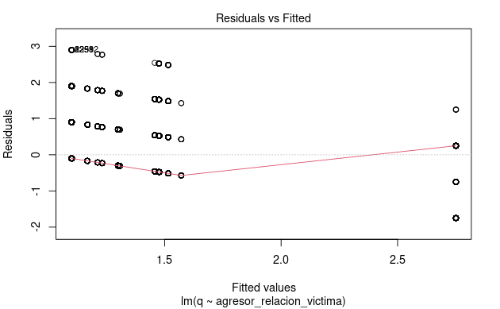

```r
modelo1 <-lm(q ~ agresor_relacion_victima , data = ds)
modelo2 <-lm(q ~ agresor_genero , data = ds)


plot(modelo1,which=1)
```

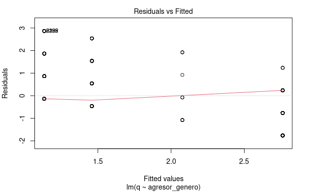

```r
plot(modelo2,which = 1)
```